# Chap 7.6

Mijeong Kim

```r
library(tsibble)
library(tsibbledata)
library(tibble)
library(dplyr)
library(knitr)
library(ggplot2)
library(fpp3)
library(fpp2)
library(seasonal)
library(feasts)
library(GGally)
```

## 7.6 Forecasting with regression

회귀 모델을 통해 $y$의 예측값은 다음과 같이 계산된다:

$$\hat{y}_t = \hat{\beta}_0 + \hat{\beta}_1 x_{1,t} + \hat{\beta}_2
x_{2,t} + \cdots + \hat{\beta}_k x_{k,t}$$

- 여기서 $\hat{\beta}_i$는 추정된 회귀 계수이고, $x_{i,t}$는 예측 변수 값이다.
- 이 식은 회귀식의 오차항을 무시하고 계산된 **결합 예측값(predicted value)**이다.

#### 적합값과 예측값의 차이

- 위 식에 **기존 관측값의 예측 변수**를 대입하면, 이는 **적합값(fitted values)**이 된다.
- 하지만 우리가 진정으로 관심 있는 것은 **미래 시점의 $y$**를 예측하는 것이다.

### Ex-ante (사전 예측) versus ex-post forecasts (사후 예측)

#### 시계열 회귀에서의 예측 유형 구분

시계열 회귀 모델을 사용할 때, **어떤 정보가 예측 시점에 사용 가능한지**에 따라  
서로 다른 유형의 예측이 존재한다. 주요 예측 방식은 **Ex-ante**와 **Ex-post** 예측이다.

#### Ex-ante Forecast (사전 예측)

- **예측 시점 이전의 정보만을 이용**하여 생성된 예측이다.
- 실제 예측 상황에 해당하며, 가장 현실적인 예측 방식이다.
- 예: 2019년 2분기까지의 데이터만을 사용해 이후 분기의 소비를 예측
- 예측 변수 $x$의 미래값이 필요하며, 이를 위해 다음과 같은 방법을 사용할 수 있다:
  - 간단한 시계열 기법 (예: 지수평활, 선형 추세 등)
  - Chapter 8, 9에서 소개되는 고급 시계열 예측법
  - 정부기관 등의 외부 예측 수치

#### Ex-post Forecast (사후 예측)

- **예측이 끝난 후 관측된 예측 변수 $x$** 값을 사용하여 수행하는 예측이다.
- 현실적인 예측은 아니며, 모델 분석 및 성능 평가 목적에 사용된다.
- 중요한 제약 조건:
  - 예측 변수 $x$는 관측값을 사용할 수 있다.
  - 그러나 예측 대상인 $y$ 값은 사용해서는 안 되며, 예측 구간의 데이터를 사용하여 모델을 재추정해서도 안 된다.

#### 예측 방식 비교의 의미

- **Ex-ante vs. Ex-post 예측 비교**를 통해 **예측 오차의 원인**을 분석할 수 있다:
  - 예측 변수 자체의 부정확성 때문인지?
  - 아니면 회귀 모델의 한계 때문인지?

이러한 분석은 예측 정확도를 개선하기 위한 중요한 단서를 제공한다.

### Example: Australian quarterly beer production

일반적으로, ex-ante 예측을 수행할 때는 예측 변수의 실제 미래 값을 사용할 수 없다. 왜냐하면 그 값들은 예측 시점에 미리 알 수 없기 때문이다.

하지만 Section 7.4에서 소개된 특수 예측 변수들은 예외이다. 이 변수들은 계절 더미 변수나 공휴일 지시 변수처럼 달력 변수에 기반하거나, 시간 추세처럼 **결정적인 함수(deterministic function)**에 기반하므로 미리 알 수 있는 값들이다.

이러한 경우에는, ex-ante 예측과 ex-post 예측 사이에 차이가 없다.

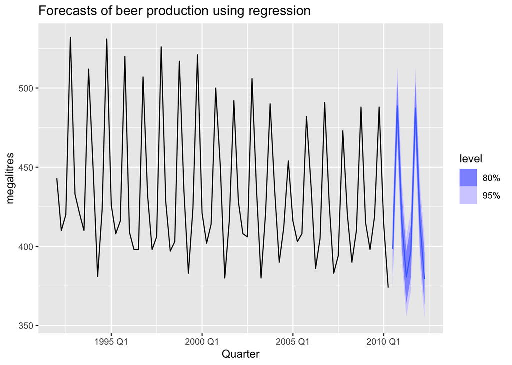

```r
recent_production <- aus_production |>
  filter(year(Quarter) >= 1992)
fit_beer <- recent_production |>
  model(TSLM(Beer ~ trend() + season()))
fc_beer <- forecast(fit_beer)
fc_beer |>
  autoplot(recent_production) +
  labs(
    title = "Forecasts of beer production using regression",
    y = "megalitres"
  )
```

Figure 7.17: Forecasts from the regression model for beer production. The dark shaded region shows 80% prediction intervals and the light shaded region shows 95% prediction intervals.

### Scenario based forecasting

시나리오 기반 예측은 예측 변수의 미래 값을 가정하여 수행하며, 이때 예측 구간은 예측 변수의 불확실성을 반영하지 않는다.

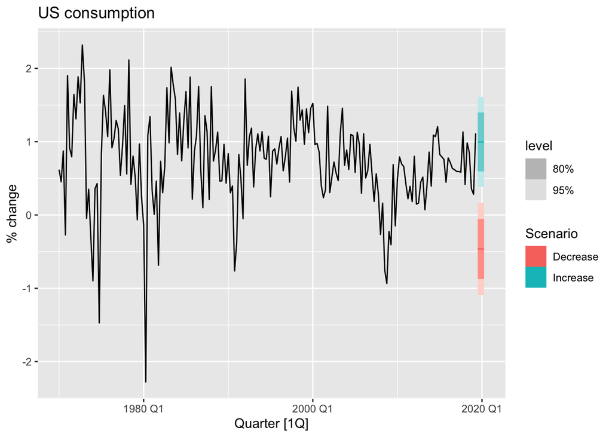

```r
fit_consBest <- us_change |>
  model(
    lm = TSLM(Consumption ~ Income + Savings + Unemployment)
  )
future_scenarios <- scenarios(
  Increase = new_data(us_change, 4) |>
    mutate(Income=1, Savings=0.5, Unemployment=0),
  Decrease = new_data(us_change, 4) |>
    mutate(Income=-1, Savings=-0.5, Unemployment=0),
  names_to = "Scenario")

fc <- forecast(fit_consBest, new_data = future_scenarios)
us_change |>
  autoplot(Consumption) +
  autolayer(fc) +
  labs(title = "US consumption", y = "% change")
```

Figure 7.18: Forecasting percentage changes in personal consumption expenditure for the US under scenario based forecasting.

### Building a predictive regression model

#### 회귀 모델의 장점

- 회귀 모델은 예측 변수와 종속 변수 간의 중요한 관계를 포착할 수 있다는 점에서 강력한 도구이다.
- 그러나 **ex-ante 예측**에서는 **미래의 예측 변수 값이 필요**하다는 점이 도전 과제가 된다.

#### 시나리오 기반 예측

- 예측 변수의 값을 직접 예측하기 어려운 경우, **가상의 미래 값을 가정**하여 예측을 수행할 수 있다.
- 이러한 방식은 **scenario-based forecasting**이라고 하며,  
  예측 구간은 **예측 변수의 불확실성은 반영하지 않는다**.

#### 지연된 예측 변수 사용 (Lagged Predictors)

- 대안으로, 예측 변수의 **지연값(lagged values)**을 사용할 수 있다.
- $h$-스텝 앞을 예측하는 경우, 다음과 같은 형태로 모델을 구성할 수 있다:

$$y_{t+h} = \beta_0 + \beta_1 x_{1,t} + \cdots + \beta_k x_{k,t} +
\varepsilon_{t+h}$$

- 여기서 사용되는 $x_{i,t}$는 모두 **$y_{t+h}$보다 h 시점 앞서 관측된 값**들이다.
- 따라서 예측 구간이 샘플 끝($T$)을 넘어서더라도,  
  **모든 예측 변수는 사용 가능한 상태**가 된다.

#### 해석상의 장점

- 예측 변수의 지연값을 포함하는 방식은 **현실적인 동태 구조**를 반영한다.
- 예: 정책 변경이 소비에 미치는 영향은 **즉시가 아닌 지연되어 나타날 수 있음**
- 이는 Section 7.4에서 소개된 **distributed lags** 개념과 관련이 있다.

#### 결론

- 예측 변수의 미래값을 알기 어렵다면, 시나리오 가정이나 지연값 활용을 통해 모델을 운영할 수 있다.
- 회귀 모델을 시계열에 맞게 일반화하는 여러 접근은 **Section 10**에서 자세히 다룬다.

### Prediction intervals

#### 예측 구간(Prediction Intervals) 개요

- 회귀 예측값에는 **예측 오차**가 존재하므로, 이를 반영한 **예측 구간(prediction interval)**이 필요하다.
- Figure 7.18에서는 각 예측값에 대해 **95% 및 80% 예측 구간**이 포함되어 있다.

#### 단순 회귀에서의 예측 구간

단순 회귀식:

$$\hat{y} = \hat{\beta}_0 + \hat{\beta}_1 x$$

정규 분포 가정을 따를 경우, **95% 예측 구간**은 다음과 같다:

$$\hat{y} \pm 1.96 \cdot \hat{\sigma}_e \cdot \sqrt{1 + \frac{1}{T} +
\frac{(x - \bar{x})^2}{(T - 1) s_x^2}}$$

- $T$: 관측치 수
- $\bar{x}$: 예측 변수 $x$의 평균
- $s_x$: 예측 변수 $x$의 표준편차
- $\hat{\sigma}_e$: 회귀 표준 오차

#### 예측 구간 해석

- $x$가 $\bar{x}$에서 멀어질수록 예측 구간은 **더 넓어진다**.
- 즉, **예측 변수의 평균에 가까운 값일수록 예측의 신뢰도는 높다.**

#### 기타 예측 구간

- **80% 예측 구간**은 위 식에서 **1.96을 1.28로 교체**하면 된다.
- 다른 신뢰수준의 예측 구간은 **표 5.1의 적절한 임계값**을 사용하면 된다.

### Example

미국 소비 예측 예제에서 추정된 단순 회귀식은 다음과 같다:

$$\hat{y}_t = 0.54 + 0.27 x_t$$

- $x_t$: 개인 소득 증가율 (%)

#### 시나리오 1: 평균 소득 증가율

- 향후 4분기 동안 소득이 **역사적 평균 $\bar{x} = 0.73\%$**만큼 증가한다고 가정할 경우:
  - 소비 예측 증가율: **0.74%**
  - **80% 예측 구간**: $[-0.02,\ 1.5]$
  - **95% 예측 구간**: $[-0.42,\ 1.9]$

#### 시나리오 2: 극단적 소득 증가율

- 소득이 **12% 증가**하는 극단적인 상황을 가정하면,
  - 예측값은 증가하지만,
  - 예측 구간은 **훨씬 더 넓어짐**
  - 이는 Figure 7.19에 시각화되어 있다.

#### 해석

- 예측 변수 $x$가 평균에서 멀어질수록 예측 구간이 넓어지며,  
  이는 예측의 불확실성이 증가함을 의미한다.

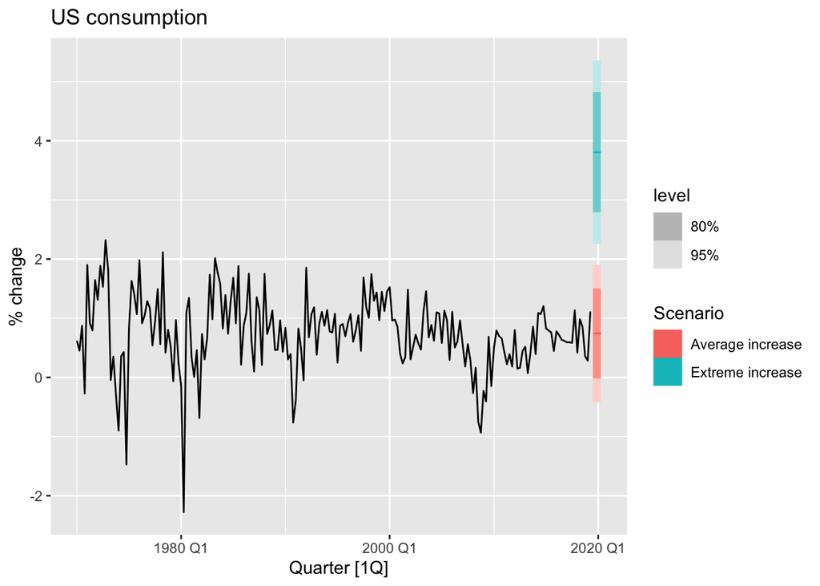

```r
fit_cons <- us_change |>
  model(TSLM(Consumption ~ Income))
new_cons <- scenarios(
  "Average increase" = new_data(us_change, 4) |>
    mutate(Income = mean(us_change$Income)),
  "Extreme increase" = new_data(us_change, 4) |>
    mutate(Income = 12),
  names_to = "Scenario"
)
fcast <- forecast(fit_cons, new_cons)

us_change |>
  autoplot(Consumption) +
  autolayer(fcast) +
  labs(title = "US consumption", y = "% change")
```

Figure 7.19: Prediction intervals if income is increased by its historical mean of  
0.73 % versus an extreme increase of 12%.